# Q4

### 1.

in this question, i fit **seasonal ARIMA (SARIMA) model** to **unemployment data** from `astsa` package.  
i have to do

1. estimate appropriate **SARIMA model**.
2. forecast unemployment for **next 12 months**.
3. provide detailed model diagnostic and report findings properly.

### 2. Load Libraries and Data

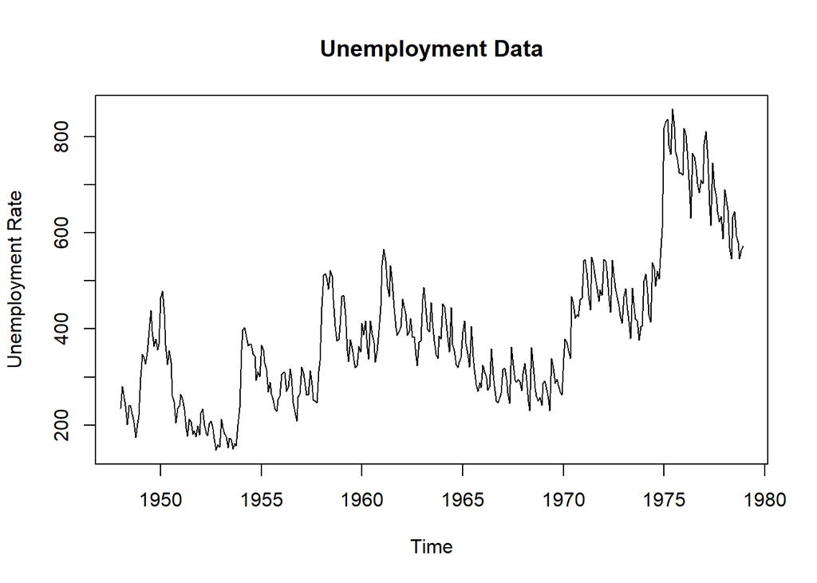

```r
# Load necessary libraries
library(forecast)
library(astsa)
library(tseries)

# Load  unemployment data
data("unemp")

# Plot  original data to visualize trends and seasonality
plot(unemp, main = "Unemployment Data", ylab = "Unemployment Rate", xlab = "Time")
```

### 2.1 Visual Analysis of Data

Looking at plot, unemployment data shows both **seasonal patterns** and **trends**.  
Thus, we need to fit **seasonal ARIMA** model.

## 3. Differencing and ACF/PACF Analysis

We first take **seasonal and non-seasonal differences** to make series stationary, then examine **ACF and PACF plots**.

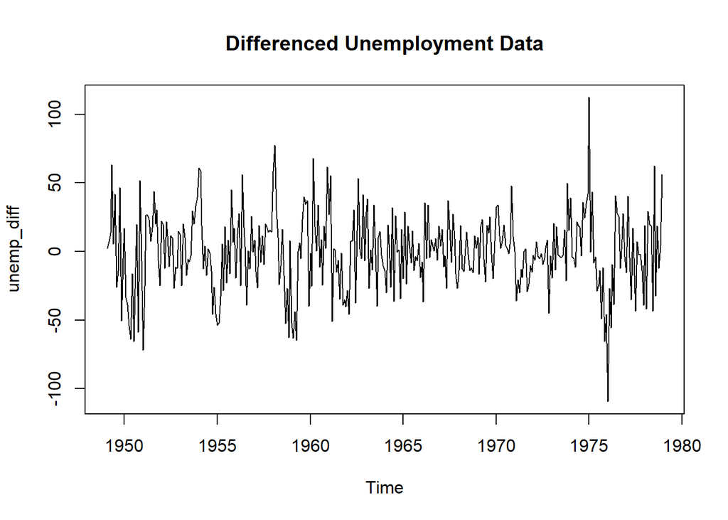

```r
# Take seasonal and non-seasonal differences
unemp_diff <- diff(diff(unemp, lag = 12))

# Plot  differenced series
plot(unemp_diff, main = "Differenced Unemployment Data")
```

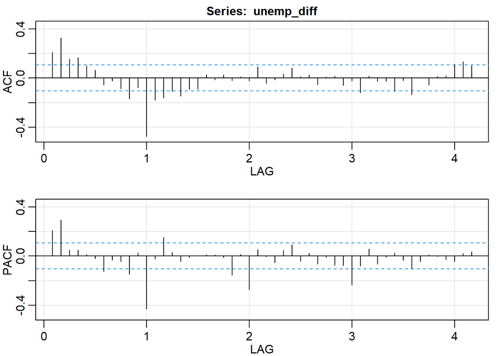

```
##         ACF  PACF
##  [1,]  0.21  0.21
##  [2,]  0.33  0.29
##  [3,]  0.15  0.05
##  [4,]  0.17  0.05
##  [5,]  0.10  0.01
##  [6,]  0.06 -0.02
##  [7,] -0.06 -0.12
##  [8,] -0.02 -0.03
##  [9,] -0.09 -0.05
## [10,] -0.17 -0.15
## [11,] -0.08  0.02
## [12,] -0.48 -0.43
## [13,] -0.18 -0.02
## [14,] -0.16  0.15
```

[output cut: 36 more lines]

```r
# ACF and PACF plots to identify model components
acf2(unemp_diff, 50)
```

## 4. Fitting SARIMA Model

```r
# Fit SARIMA(2, 1, 0) x (0, 1, 1)[12] model
sarima_model <- sarima(unemp, p = 2, d = 1, q = 0, P = 0, D = 1, Q = 1, S = 12)
```

[figure not shown]

## 5. Forecasting for Next 12 Months

We now use estimated SARIMA model to forecast unemployment for next 12 months.

```r
# Forecast for  next 12 months
forecast_sarima <- sarima.for(unemp, n.ahead = 12, p = 2, d = 1, q = 0, P = 0, D = 1, Q = 1, S = 12)
```

[figure not shown]

[figure not shown]

```r
# Convert forecast to time series object for plotting
forecast_ts <- ts(forecast_sarima$pred,
                  start = end(unemp)[1] + c(0, 1),
                  frequency = 12)

# Plot  original data along with  forecast
ts.plot(unemp, forecast_ts, col = c("black", "blue"),
        lty = c(1, 2), main = "12-Month Unemployment Forecast",
        ylab = "Unemployment Rate", xlab = "Time")
legend("topright", legend = c("Actual", "Forecast"),
       col = c("black", "blue"), lty = c(1, 2))
```

## 6. Model Diagnostics

We assess residuals of model to ensure they behave like white noise.

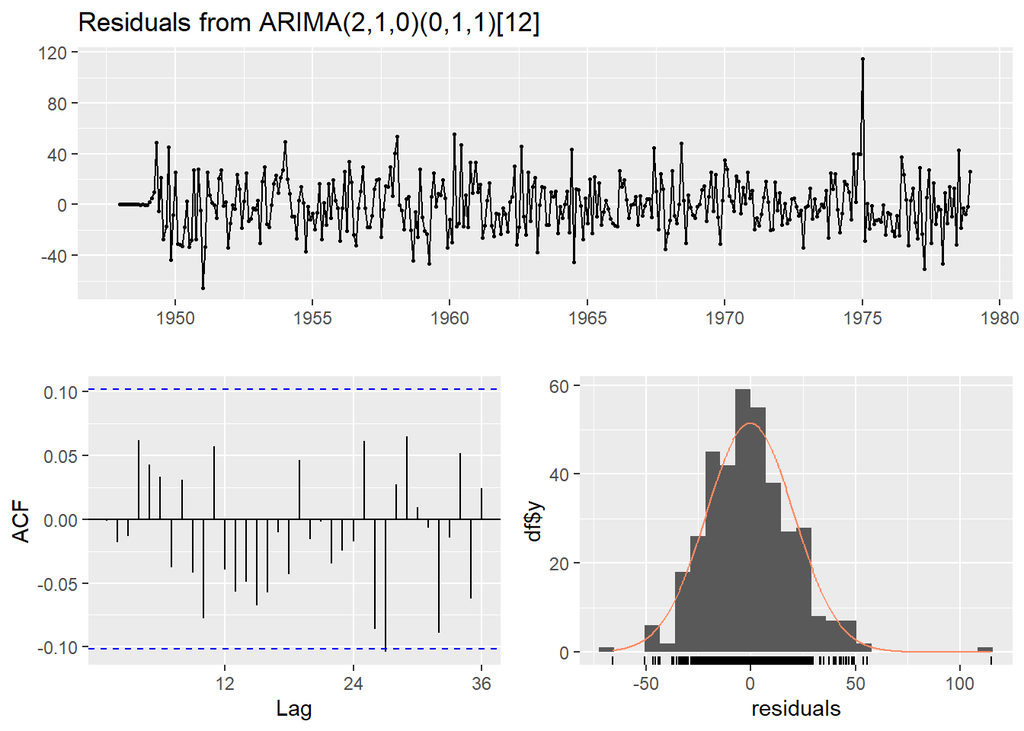

```
##
##  Ljung-Box test
##
## data:  Residuals from ARIMA(2,1,0)(0,1,1)[12]
## Q* = 16.378, df = 21, p-value = 0.7481
##
## Model df: 3.   Total lags used: 24
```

```r
# Check residuals for normality and autocorrelation
checkresiduals(sarima_model$fit)
```

### 6.1 Residual Analysis

- **Ljung-Box Test**: If p-value > 0.05, residuals are uncorrelated.
- **Normality**: Evaluate Q-Q plot and histogram of residuals for normality.

## 7. Conclusion

Based on **SARIMA(2, 1, 0) × (0, 1, 1)[12]** model, unemployment forecast for next 12 months shows:

1. **seasonal trend**, with expected fluctuations over months.
2. model fits data well, with residuals behaving like white noise.
3. **Forecasts**: Provide insight into unemployment rates for upcoming year.

## 8. Summary of Findings

- **Model Selection**: chosen SARIMA(2, 1, 0) × (0, 1, 1)[12] model was based on ACF/PACF analysis.
- **Forecasting**: forecast suggests continued seasonal variation in unemployment.
- **Model Fit**: Diagnostics indicate model fits data well, with uncorrelated residuals.